# Practical Machine Learning - Project 1

Sarabjeet Singh

Friday, May 22, 2015

# Background

Using devices such as Jawbone Up, Nike FuelBand, and Fitbit it is now possible to collect a large amount of data about personal activity relatively inexpensively. These type of devices are part of the quantified self movement. The data sets used for this project are from website  
http://groupware.les.inf.puc-rio.br/har on Weight Lifting Exercises Dataset.

Reference : Velloso, E.; Bulling, A.; Gellersen, H.; Ugulino, W.; Fuks, H. Qualitative Activity Recognition of Weight Lifting Exercises. Proceedings of 4th International Conference in Cooperation with SIGCHI (Augmented Human ’13) . Stuttgart, Germany: ACM SIGCHI, 2013.

Six young health participants were asked to perform one set of 10 repetitions of the Unilateral Dumbbell Biceps Curl in five different fashions:

- exactly according to the specification (Class A),
- throwing the elbows to the front (Class B),
- lifting the dumbbell only halfway (Class C),
- lowering the dumbbell only halfway (Class D)
- throwing the hips to the front (Class E).

# Read the Data

Downloaded the two .csv files on Training and Testing.

```r
train <- read.csv("pml-training.csv")
test <- read.csv("pml-testing.csv")
dim(train)
```

```
## [1] 19622   160
```

```r
dim(test)
```

```
## [1]  20 160
```

training dataset has 19622 observations and 160 variables, while the testing data set contains 20 observations and 160 variables. “classe” variable in the training set is the outcome to predict.

# Clean the data

We will clean the data and get rid of observations with missing values as well as some meaningless variables.

```r
# Clean data containing NA.
train <- train[, colSums(is.na(train)) == 0]
test <- test[, colSums(is.na(test)) == 0]
# clean data from features not from the sensors
trainC <- train[, grepl("X|user_name|timestamp|window|^max|^min|^ampl|^var|^avg|^stdd|^ske|^kurt", colnames(train)) == F]
testC <- test[, grepl("X|user_name|timestamp|window|^max|^min|^ampl|^var|^avg|^stdd|^ske|^kurt",
    colnames(test)) == F]
dim(trainC)
```

```
## [1] 19622    53
```

```r
dim(testC)
```

```
## [1] 20 53
```

Now the cleaned data contains 53 variables down from 160 varaibles earlier

# Slice the Data

we can split the cleaned training set into a pure training data set (70%) and a validation data set (30%). We will use the validation data set to conduct cross validation in future steps.

```r
library(caret)
set.seed(25000) # For reproducibile purpose
inTrain <- createDataPartition(trainC$classe, p=0.70, list=F)
trainX <- trainC[inTrain, ]
validX <- trainC[-inTrain, ]
```

# Data Modeling

We can use a predictive model for activity recognition using Random Forest algorithm. We can use 10-fold cross validation when applying the algorithm.

```r
library(randomForest)
library(e1071)  # I found this error hence using this library : Error in requireNamespaceQuietStop("e1071") : package e1071 is required
controlRf <- trainControl(method="cv", 10)
modelRf <- train(classe ~ ., data=trainX, method="rf", trControl=controlRf, ntree=100, allowParallel=TRUE)
modelRf
```

```
## Random Forest
##
## 13737 samples
##    52 predictor
##     5 classes: 'A', 'B', 'C', 'D', 'E'
##
## No pre-processing
## Resampling: Cross-Validated (10 fold)
##
## Summary of sample sizes: 12364, 12364, 12362, 12365, 12362, 12362, ...
##
## Resampling results across tuning parameters:
##
##   mtry  Accuracy   Kappa      Accuracy SD  Kappa SD
##    2    0.9901732  0.9875684  0.003183570  0.004026930
##   27    0.9914823  0.9892251  0.002118729  0.002680416
##   52    0.9843483  0.9802003  0.004050234  0.005124600
##
## Accuracy was used to select the optimal model using  the largest value.
## The final value used for the model was mtry = 27.
```

Then we predict this modeling on validation data set

```r
predictRf <- predict(modelRf, validX)
confusionMatrix(validX$classe, predictRf)
```

```
## Confusion Matrix and Statistics
##
##           Reference
## Prediction    A    B    C    D    E
##          A 1667    5    1    0    1
##          B    6 1130    3    0    0
##          C    0    6 1013    7    0
##          D    0    0   14  950    0
##          E    0    1    2    2 1077
##
## Overall Statistics
##
##                Accuracy : 0.9918
##                  95% CI : (0.9892, 0.994)
##     No Information Rate : 0.2843
##     P-Value [Acc > NIR] : < 2.2e-16
##
##                   Kappa : 0.9897
##  Mcnemar's Test P-Value : NA
##
## Statistics by Class:
##
##                      Class: A Class: B Class: C Class: D Class: E
## Sensitivity            0.9964   0.9895   0.9806   0.9906   0.9991
## Specificity            0.9983   0.9981   0.9973   0.9972   0.9990
## Pos Pred Value         0.9958   0.9921   0.9873   0.9855   0.9954
## Neg Pred Value         0.9986   0.9975   0.9959   0.9982   0.9998
## Prevalence             0.2843   0.1941   0.1755   0.1630   0.1832
## Detection Rate         0.2833   0.1920   0.1721   0.1614   0.1830
## Detection Prevalence   0.2845   0.1935   0.1743   0.1638   0.1839
## Balanced Accuracy      0.9974   0.9938   0.9890   0.9939   0.9990
```

Lets check Accuracy

```r
accuracy <- postResample(predictRf, validX$classe)
accuracy
```

```
##  Accuracy     Kappa
## 0.9918437 0.9896834
```

Accuracy of this prediction model is 99.18%.

Out of Sample Error is calculated here

```r
error <- 1 - as.numeric(confusionMatrix(validX$classe, predictRf)$overall[1])
error
```

```
## [1] 0.00815633
```

Out of Sample Error is 0.82%.

# Predicting for Test Data Set

Now, we apply the model to the original testing data set downloaded from the data source. Generate “problem_id_x.txt” Files for the assignments. These generated individual files are stored in working directory.

```r
Testpredict <- predict(modelRf, testC, type = "raw")
pml_write_files = function(x){
  n = length(x)
  for(i in 1:n){
    filename = paste0("problem_id_",i,".txt")
    write.table(x[i],file=filename,quote=FALSE,row.names=FALSE,col.names=FALSE)
  }
}
pml_write_files(Testpredict)
```

Loaded these files as per Problem_id number into Project Assignment and obtained the correct results for all 20 cases.

# Appendix : Tree Visualization

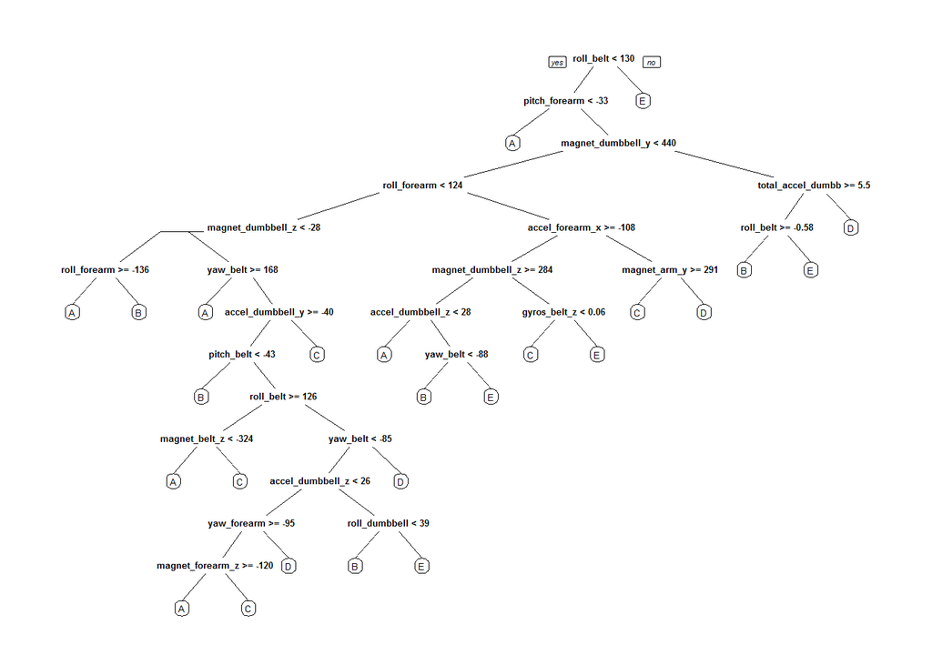

```r
library(rpart)
library(rpart.plot)
treeModel <- rpart(classe ~ ., data=trainX, method="class")
prp(treeModel) # plot of Tree Model
```